# Can We Predict Google App Rating?(Linear Regression)

#### Predicting Value of Rating

- If we use this best fit line function for predicting Rating by using any random value of Reviews or if any google App developer wants to predict of his developed App Rating by inputing value of App total number of Reviews.
- lets say for example if we take 100,000 Reviews than what would be App Rating.

```r
a <- 4.16014089403 + (0.000000012477 * 100000)
a
```

```
## [1] 4.161389
```

```r
google_modeling %>%  filter(between(Reviews,99999,100111))
```

| Rating | Reviews | Installs |
| --- | --- | --- |
| 4.9 | 100082 | 1000000 |

- Closest Value to in our actual data corresponds to Reviews = 100082 so we will use this value to calculate the residual.
- Residual Value is difference between Actual value and predicted value.

**When our Total Reviews are 100,000 than our model predicted value of Rating is 4.16.**

**But in Our Data Set when Total Reviews are 100,082 than Actual Value of Rating is 4.9.**

#### Calculating Residual

**We got Positive value of our Residual that means the value predicted by our model is an underestimate.**

```r
model_residual <- 4.9 - 4.1
model_residual
```

```
## [1] 0.8
```

#### **Diagnosis of Model 1**

- To check weather our created linear model is reliable or not there are three ways through which we can check.
  - Checking Linearity.
  - Checking Normality in Residuals.
  - Checking Constant Variability.

#### Checking Linearity

- As ploted above scater plot from that we can find there is very weak positive linear relationship between Rating and Reviews.
- Here we will use Broom package which help us to calculate all residual values from our linear model which we created above using lm() function.

```r
summary(model1)
```

```
##
## Call:
## lm(formula = Rating ~ Reviews, data = google_modeling)
##
## Residuals:
##      Min       1Q   Median       3Q      Max
## -3.16014 -0.16014  0.03981  0.33397  0.83986
##
## Coefficients:
##                   Estimate     Std. Error t value             Pr(>|t|)
## (Intercept) 4.160140894026 0.004682810971  888.38 < 0.0000000000000002 ***
## Reviews     0.000000012477 0.000000001581    7.89  0.00000000000000332 ***
## ---
## Signif. codes:  0 '***' 0.001 '**' 0.01 '*' 0.05 '.' 0.1 ' ' 1
##
## Residual standard error: 0.482 on 10838 degrees of freedom
## Multiple R-squared:  0.005711,   Adjusted R-squared:  0.005619
## F-statistic: 62.25 on 1 and 10838 DF,  p-value: 0.000000000000003318
```

```r
library(broom)

model1_residuals<- augment(model1) %>%
            select(Rating, Reviews, predicted = .fitted, residuals = .resid)
model1_residuals
```

| Rating | Reviews | predicted | residuals |
| --- | --- | --- | --- |
| 4.1 | 159 | 4.160143 | -0.060142878 |
| 3.9 | 967 | 4.160153 | -0.260152959 |
| 4.7 | 87510 | 4.161233 | 0.538767230 |
| 4.5 | 215644 | 4.162832 | 0.337168483 |
| 4.3 | 967 | 4.160153 | 0.139847041 |
| 4.4 | 167 | 4.160143 | 0.239857022 |
| 3.8 | 178 | 4.160143 | -0.360143115 |
| 4.1 | 36815 | 4.160600 | -0.060600240 |
| 4.4 | 13791 | 4.160313 | 0.239687034 |
| 4.7 | 121 | 4.160142 | 0.539857596 |

[output cut: 9990 more lines]

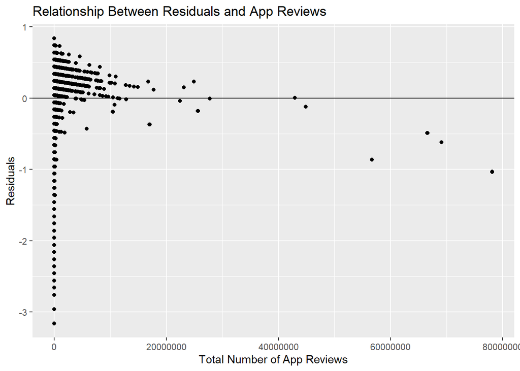

```r
ggplot(model1_residuals, aes(x = Reviews, y = residuals)) +
  geom_point() +
  geom_hline(yintercept = 0)+
  xlab("Total Number of App Reviews")+
  ylab("Residuals") +
  ggtitle("Relationship Between Residuals and App Reviews")
```

- From Above plot we can see that their unique pattern that most of Residuals are between -1 to 1 which also prooves weak linear or no relationship between Rating and Reviews, So first condition “linearity” is not met.

#### Checking Normal Residuals

- Based on Graph of Histogram we can see our Residuals are not normally distributed So our Second condtion is not met.

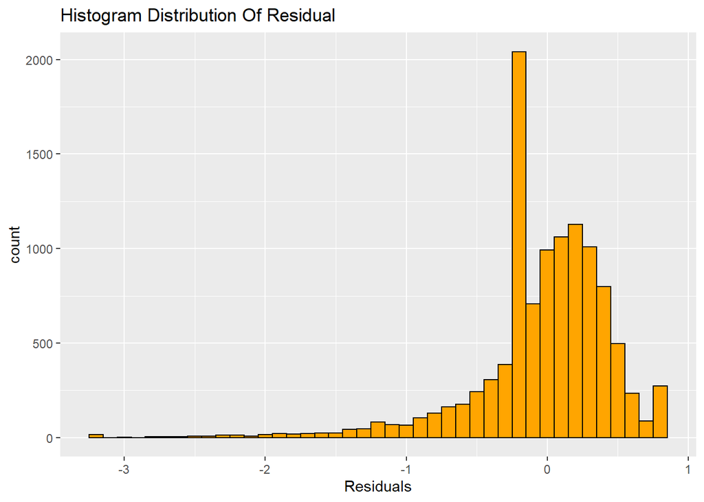

```r
ggplot(model1_residuals, aes(x = residuals)) +
  geom_histogram(fill = 'orange', colour = 'black',binwidth = 0.1)+
  xlab("Residuals")+
  ggtitle("Histogram Distribution Of Residual")
```

#### Checking Constant Variability

- Below Scatter plot suggest us that Most of our residual points are between two horizontal red lines but it is very close to 0 and their is no constant increase or decrease which tells us that there is not constant variability in our data.
- So our third condition for model diagnosis is not met.

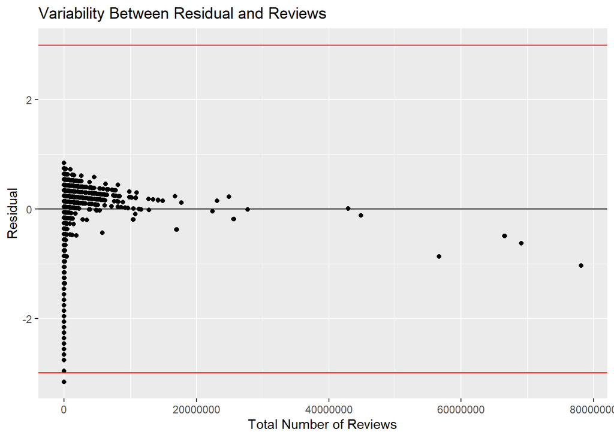

```r
ggplot(model1_residuals, aes(x = Reviews, y = residuals)) +
  geom_point() +
  geom_hline(yintercept = 0) +
  geom_hline(yintercept = 3, colour = 'red') +
  geom_hline(yintercept = -3, colour = 'red') +
  xlab("Total Number of Reviews")+
  ylab("Residual")+
  ggtitle("Variability Between Residual and Reviews")
```

#### **Model 2: Rating and Installs**

#### Visualizing Relationship

- Here we would use Scatter plot to display relationship between Rating and another numerical variable.
- Rating is our Response variable we will put it on Y-axis and Installs is our explanatory variable we will put it on X-axis.

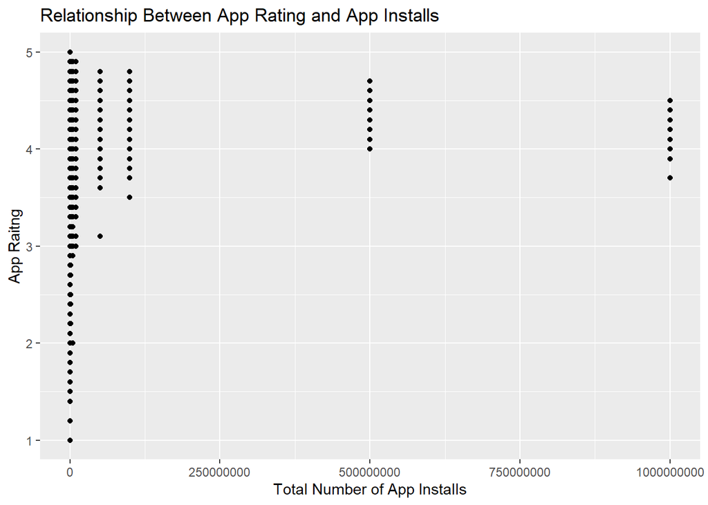

```r
ggplot(google_modeling,aes(x=Installs,y=Rating))+
  geom_point()+
  xlab("Total Number of App Installs")+
  ylab("App Raitng") +
  ggtitle("Relationship Between App Rating and App Installs")
```

#### Finding Relationship

```r
cor(google_modeling$Rating,google_modeling$Installs)
```

```
## [1] 0.06055361
```

#### Checking Strength,Direction,Form

- strength of relation is very weak or no relation and it is positive relation with correlation value of 0.06055361.
- there are some observations in our relationship is that most of rating is between 4 to 5 so most of data points are between this two rating.

#### Creating linear Model

```r
model2  <- lm(Rating ~ Installs,data=google_modeling)
model2
```

```
##
## Call:
## lm(formula = Rating ~ Installs, data = google_modeling)
##
## Coefficients:
##     (Intercept)         Installs
## 4.1603590486652  0.0000000003443
```

```r
summary(model2)
```

```
##
## Call:
## lm(formula = Rating ~ Installs, data = google_modeling)
##
## Residuals:
##      Min       1Q   Median       3Q      Max
## -3.16036 -0.16036  0.03961  0.33620  0.83964
##
## Coefficients:
##                     Estimate       Std. Error t value             Pr(>|t|)
## (Intercept) 4.16035904866520 0.00471062229394 883.187 < 0.0000000000000002 ***
## Installs    0.00000000034425 0.00000000005451   6.316        0.00000000028 ***
## ---
## Signif. codes:  0 '***' 0.001 '**' 0.01 '*' 0.05 '.' 0.1 ' ' 1
##
## Residual standard error: 0.4825 on 10838 degrees of freedom
## Multiple R-squared:  0.003667,   Adjusted R-squared:  0.003575
## F-statistic: 39.89 on 1 and 10838 DF,  p-value: 0.0000000002797
```

- Lm model it gives us our intercept and Slope values which are two elements of best fit line for predicting response variable.
- summary function gives us summary regarding our model it gives us five number summary for our model, coefficients which gives us our Estimated Slope and intercept.
- Based upon above we can create our least squares regression line which in this case it would be **rating = 4.1603 + 0.00000000034425 * Installs** .
- The value of R square represents the proportion of variability in the response variable that is explained by the explanatory variable. For this model, 0.37% of the variability in Rating is explained by Installs which is too less or like nothing.

#### Fitting Best line on plot

- By plotting our best fit line on plot we can see difference between Actual value and best fit line.We can plot our best fit line using geom_abline() function.
- Now using this best fit line we can predict y for any value x which is predict Rating for any value of Installs.

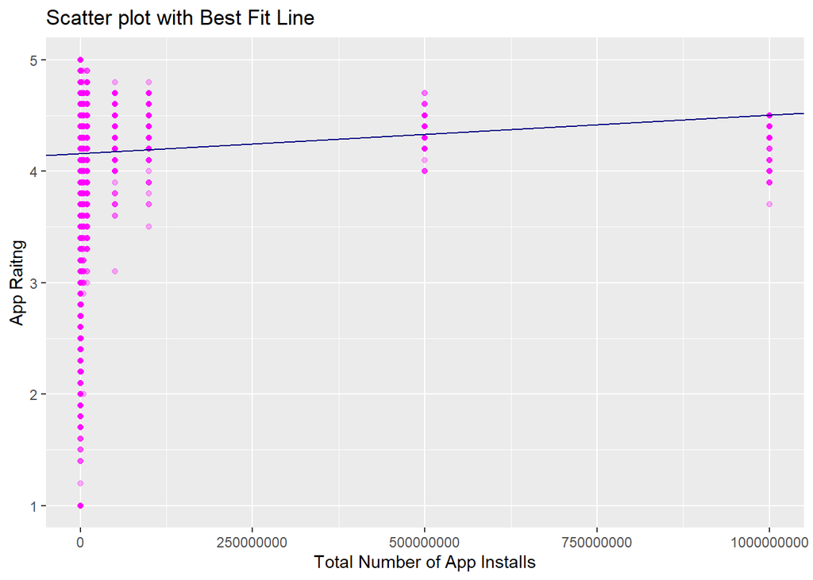

```r
ggplot(google_modeling,aes(x=Installs,y=Rating))+
  geom_point(alpha =0.3,col="magenta") +
  geom_abline(slope =0.00000000034425, intercept = 4.16035904866520,col="Navyblue")+
  xlab("Total Number of App Installs")+
  ylab("App Raitng") +
  ggtitle("Scatter plot with Best Fit Line")
```

#### Predicting Value of Rating

- If we use this best fit line function for predicting Rating by using any random value of Installs or if any google App developer wants to predict of his developed App Rating by inputing value of App total number of Installs.
- lets say for example if we take 1,000,000,000 Installs than what would be App Rating.

```r
b <- 4.16035904866520 + (0.00000000034425 * 1000000000)
b
```

```
## [1] 4.504609
```

```r
google_modeling %>%  filter(between(Installs,999999999,1000000001))
```

| Rating | Reviews | Installs |
| --- | --- | --- |
| 3.9 | 1433233 | 1000000000 |
| 4.0 | 56642847 | 1000000000 |
| 4.4 | 69119316 | 1000000000 |
| 4.3 | 9642995 | 1000000000 |
| 4.3 | 4604324 | 1000000000 |
| 4.0 | 3419249 | 1000000000 |
| 4.4 | 69119316 | 1000000000 |
| 4.0 | 56646578 | 1000000000 |
| 4.0 | 3419433 | 1000000000 |
| 4.1 | 10484169 | 1000000000 |

[output cut: 48 more lines]

```r
google_modeling %>%  filter(between(Installs,999999999,1000000001)) %>% summarise(mean(Rating))
```

| mean(Rating) |
| --- |
| 4.258621 |

- In our Actual Data there are 58 App which are having Installs of 1,000,000,000 so in that case we will take mean value from them and take that value for counting residual.
- Residual Value is difference between Actual value and predicted value.

**When our Total Installs are 1,000,000,000 than our model predicted value of Rating is 4.50.**

**But in Our Data Set when Total Install are 1,000,000,000 than Actual Value of Rating is 4.26.**

#### Calculating Residual

**We got Negative value of our Residual that means the value predicted by our model is an Overestimate**.

```r
model_residual_2 <- 4.26 - 4.50
model_residual_2
```

```
## [1] -0.24
```

#### **Diagnosis of Model 2**

- To check weather our created linear model is reliable or not there are three ways through which we can check.
  - Checking Linearity.
  - Checking Normality in Residuals.
  - Checking Constant Variability.

#### Checking Linearity

- As ploted above scater plot from that we can find there is very weak positive linear relationship between Rating and Installs
- Here we will use Broom package which help us to calculate all residual values from our linear model which we created above using lm() function.

```r
summary(model2)
```

```
##
## Call:
## lm(formula = Rating ~ Installs, data = google_modeling)
##
## Residuals:
##      Min       1Q   Median       3Q      Max
## -3.16036 -0.16036  0.03961  0.33620  0.83964
##
## Coefficients:
##                     Estimate       Std. Error t value             Pr(>|t|)
## (Intercept) 4.16035904866520 0.00471062229394 883.187 < 0.0000000000000002 ***
## Installs    0.00000000034425 0.00000000005451   6.316        0.00000000028 ***
## ---
## Signif. codes:  0 '***' 0.001 '**' 0.01 '*' 0.05 '.' 0.1 ' ' 1
##
## Residual standard error: 0.4825 on 10838 degrees of freedom
## Multiple R-squared:  0.003667,   Adjusted R-squared:  0.003575
## F-statistic: 39.89 on 1 and 10838 DF,  p-value: 0.0000000002797
```

```r
library(broom)

model2_residuals<- augment(model2) %>%
            select(Rating, Installs, predicted = .fitted, residuals = .resid)
model2_residuals
```

| Rating | Installs | predicted | residuals |
| --- | --- | --- | --- |
| 4.1 | 10000 | 4.160362 | -0.060362491 |
| 3.9 | 500000 | 4.160531 | -0.260531174 |
| 4.7 | 5000000 | 4.162080 | 0.537919698 |
| 4.5 | 50000000 | 4.177572 | 0.322428421 |
| 4.3 | 100000 | 4.160393 | 0.139606526 |
| 4.4 | 50000 | 4.160376 | 0.239623739 |
| 3.8 | 50000 | 4.160376 | -0.360376261 |
| 4.1 | 1000000 | 4.160703 | -0.060703299 |
| 4.4 | 1000000 | 4.160703 | 0.239296701 |
| 4.7 | 10000 | 4.160362 | 0.539637509 |

[output cut: 9990 more lines]

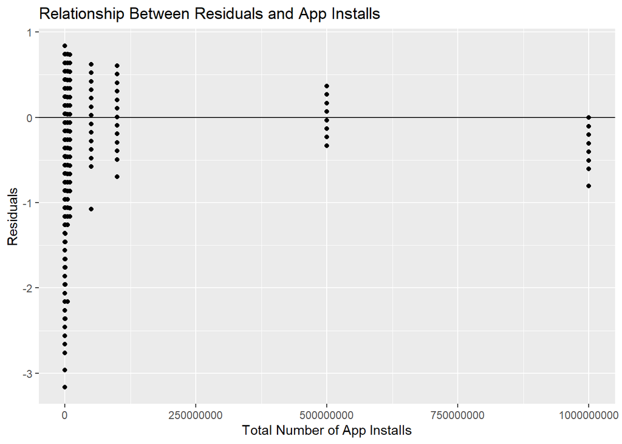

```r
ggplot(model2_residuals, aes(x = Installs, y = residuals)) +
  geom_point() +
  geom_hline(yintercept = 0)+
  xlab("Total Number of App Installs")+
  ylab("Residuals") +
  ggtitle("Relationship Between Residuals and App Installs")
```

- From Above plot we can see that their unique pattern that most of Residuals are between -1 to 1 which also prooves weak linear relationship or no relationship between Rating and Installs, So first condition “linearity” is not met.

#### Checking Normal Residuals

- Based on Graph of Histogram we can see our Residuals are not normally distributed So our Second condtion is not met.

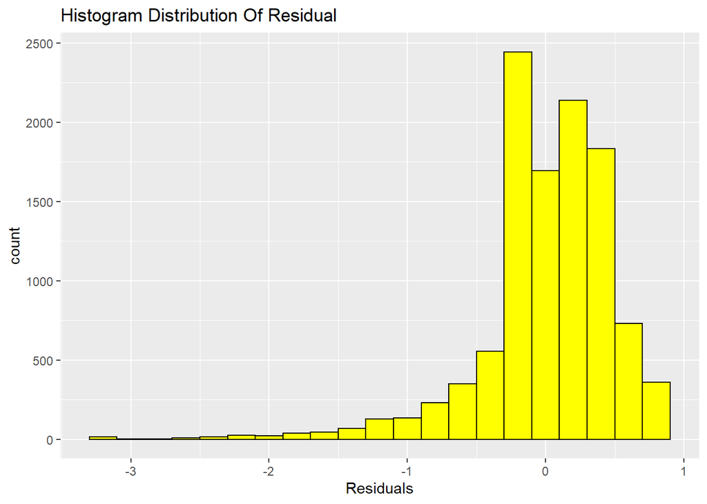

```r
ggplot(model2_residuals, aes(x = residuals)) +
  geom_histogram(fill = 'yellow', colour = 'black',binwidth =0.2)+
  xlab("Residuals")+
  ggtitle("Histogram Distribution Of Residual")
```

#### Checking Constant Variability

- Below Scatter plot suggest us that Most of our residual points are between two horizontal red lines but it is very close to 0 and their is not constant increase or decrease which tells us that there is not constant variability in our data.
- So our third condition for model diagnosis is not met.

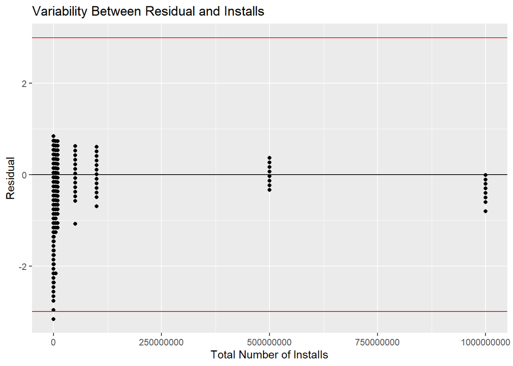

```r
ggplot(model2_residuals, aes(x = Installs, y = residuals)) +
  geom_point() +
  geom_hline(yintercept = 0) +
  geom_hline(yintercept = 3, colour = 'red') +
  geom_hline(yintercept = -3, colour = 'red') +
  xlab("Total Number of Installs")+
  ylab("Residual")+
  ggtitle("Variability Between Residual and Installs")
```

#### Comparing Both Model

- Model1 **Rating and Reviews** is having correlation of **0.07556965** and their R Square value is **0.005711**
- Model2 **Rating and Installs** is having correlation of **0.06055361** and their R Square value is **0.003667.**
- If we consider above values we can say that model 1 is good than model 2 becasuse it is having better Correlation and R square value.
- However,Main issue with this model is that it is not reliable because when we tried to check diagnosis of our model it failed to match all three conditions and they are having weak or no correlation so **we can not use this model to predict App Rating.**

> **END OF SECTION 2**

## **Section 3 - Final analysis report:**

- Our Main Hypothesis is to predict App Rating(Response) Based upon App Reviews(Explanatory) and App Total Number of Installs(Explanatory) Or to Find Relationship Between These Three Variable.Are they have any relationship between them?
- We started with an assumption in our mind that we can predict App Rationg Using App Reviews and App Total Number of Installs Or there is relationship between this variable.
- Now in order to check our hypothesis correct or wrong we have gone through sevral Steps which are following:
  - First we tried to get overall knowledge of our Dataset with what each variable stands for and what type of values contains specially with our main hypothesis variables.
  - After getting knowledge of data we tried to clean our dataset to make it competible for doing analysis.
  - Before Jumping into Exploratory Data Analysis we visualized our data to get more better understanding of dataset.For Example we found that Most of App Rating are between 4 to 5,Out all App Category Game category is having highest numer of Reviews and Installs,Also Most of App are of Free type,In Game Category App Highest Action Genres are of them,Most type of content rating is given by everyone and All Paid App is having Price within 40$.
  - During Our Exploratory Data Analysis we took both Rating(Response) and Reviews(Explanatory), Installs(Explanatory) variable to do univariate Analysis on each of this individually also bivariate analysis between combinations of two.We have found Skewness,outliers and measure of spread,centeral tendency for each of these variable.We also found relationship between this variables.
  - At last We did data modeling by applying Linear model aslo plotted best fitting line to check correctness of our hypothesis.we created two models one for Rating(Response) and Reviews(Explanatory) second for Rating(Response) and Installs(Explanatory).
  - We found slope and intercept values as well as correlation for both model and manually tried to find Residual values based upon Actual and predicted values.We also diagnose our model by checking three conditions Of linearity,normal residuals and constant variability.
  - From result of our model we found that both model failed to pass our hypothesis test because they were having very weak or no correlation value and not matching all three conditions of model diagnosis.
  - From Above all we can say that our hypothesis failed or proved wrong that we can not predict value of App Rating(Response) using App Reviews(Explanatory) and Installs(Explanatory) or there is no relationship between these three variables.
  - Any Google play store developer use this model to predict his own developed app rating based upon app reviews and app installs he won’t be able to predict rating of it.

> **END OF SECTION 3**

## **Section 4- Conclusion/Summary**

#### In our project we used Google Play store dataset from which we created our research question to predict App Rating using App Reviews and App Installs.In order to find our research anlaysis we analyzed and processed our data.After handling our data we used various statistical techniques like Univariate,Bivariate Analysis of Response and explanatory variable.For doing prediction we used linear model method which helped to generate a best fit line equation through that we can predict Rating of App for any given App Reviews and App installs.Residuals helped to understand constant variability in our model as well as reliability of our model.What we learned from our whole analysis is that variable we choose for doing analysis were not highly correlated to each other becasuse of that our linear model was not able to predict our response variable.As matter of fact dataset we choose was may be wrong instead of taking whole dataset we could have divided into small parts like finding only App Rating which has value above 4 with App Reviews and App installs than it might have predicted well.In case of statistical analysis approach our model of linear model was appropriate for predicting app rating but there were some issues with variables which we choose to apply on the model like Review and Installs variables are having very large values in millions and billions that can not help us to predict rating.

#### what we would do next if we were going to continue work on the project: There are lots of other things which we can do with this dataset such as like:

- Here we have taken Installs and Reviews on their actual values which have very large values in millions and billions so instead of taking whole dataset we should either restrict ourself to particular value like upto 1,00,000 Reviews and Installs or divided into various ranges than tried to predict Rating than result could be different.
- We could find relationship between App Last Updated,Current Android version and App Rating or does Updation of App has relation with App rating.Any play store app developer who keeps updated their app with new patches and features will have good chances of getting App higher rating.
- In our dataset there are high number of Game App that we can take all Game App data than we can do analysis between Free and Paid Game apps based upon we can decide which one is better to download.
- We have one Variable Type which says weather a App is Free or paid. we can do classification on this varibale based upon other variables such as Rating,Reviews,Size and installs to correctly classify weather it would be a free or paid App.
- We can also find relationship between App size and App Price to find out weather Paid App has large App size or Free App have Large App size or via versa.

> **END OF SECTION 4**

### References Links:

— https://www.kaggle.com/asethi129/eda-on-play-store-data-which-games-to-buy.

— https://www.kaggle.com/rtrench/practicing-eda/code.

— https://discuss.analyticsvidhya.com/t/how-to-count-the-missing-value-in-r/2949.

— https://stackoverflow.com/questions/25835643/replace-missing-values-with-column-mean.

— https://www.kaggle.com/rtrench/practicing-eda#univariate-analysis

— https://www.kaggle.com/geethas/eda-google-rating

— https://stackoverflow.com/questions/44089894/identifying-the-outliers-in-a-data-set-in-r/44089981

— https://www.r-bloggers.com/make-a-box-plot-with-single-column-data-using-ggplot2-tutorial/

— https://www.r-bloggers.com/outlier-detection-and-treatment-with-r/

— https://medium.com/@ertebablu_7511/google-app-store-rating-prediction-ffa7343cf1be